# Analisis sobre Encuentas de Eleciciones Presidenciales en Argentina (2023)

2024-10-19

# **Primer Analisis**

Queriamos empezar el analisis sabiendo cuantas observaciones y variables teniamos en la encuesta

```
##  [1] "Marca temporal"          "mail"
##  [3] "edad"                    "genero"
##  [5] "generales"               "balotaje"
##  [7] "problemas_inflacion"     "problemas_inseguridad"
##  [9] "problemas_pobreza"       "problemas_desempleo"
## [11] "problemas_corrupcion"    "problemas_desigualdad"
## [13] "problemas_educacion"     "problemas_deficit"
## [15] "orden_inflacion"         "orden_inseguridad"
## [17] "orden_pobreza"           "orden_desempleo"
## [19] "orden_corrupcion"        "orden_desigualdad"
## [21] "orden_educacion"         "orden_deficit"
## [23] "politicas_tarifas"       "politicas_boleto"
## [25] "politicas_impuestos"     "politicas_obras"
## [27] "politicas_universidades" "imagen_milei"
## [29] "imagen_grabois"          "imagen_bullrich"
## [31] "imagen_villarruel"       "imagen_llaryora"
## [33] "imagen_kicillof"         "imagen_moreno"
## [35] "imagen_deloredo"         "imagen_cfk"
## [37] "imagen_macri"            "control_precios"
## [39] "control_privatizacion"   "control_punibilidad"
```

```
## [1] 925
```

Ya sabiendo la cantidad de observaciones y tambien cuales eran las variables. Decidimos saber cuales eran las edades de las personas encuestadas

```
##    Min. 1st Qu.  Median    Mean 3rd Qu.    Max.
##   16.00   26.00   39.00   41.21   53.00   92.00
```

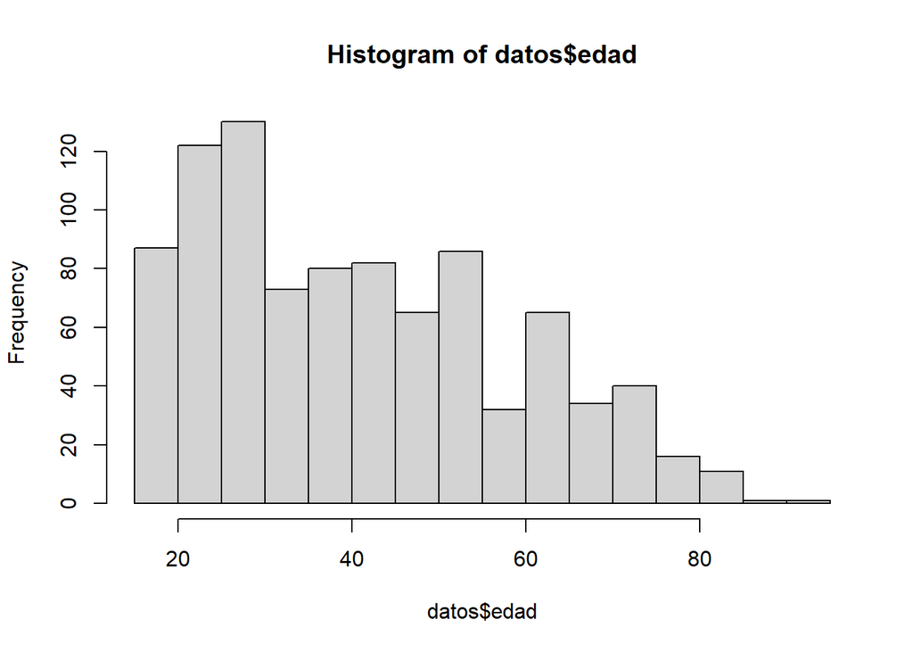

Ya viendo la distribución de edades, tambien queriamos fijarnos en la distribución de generos dentro de la encuesta

| Genero | Frecuencia |
| --- | --- |
| mujer | 452 |
| mujer trans / travesti | 4 |
| no binario | 5 |
| otra identidad / ninguna de las anteriores | 2 |
| Prefiero no contestar | 2 |
| varón | 456 |
| varón trans / masculinidad trans | 4 |

Y para terminar este analisis inicial queriamos ver como fueron las votaciones de las personas encuestadas en las elecciones generales primeramente

| Candidato | Cantidad de Votos |
| --- | --- |
| En blanco | 29 |
| Javier Milei | 253 |
| Juan Schiaretti | 130 |
| Miriam Bregman | 52 |
| No me acuerdo | 5 |
| No voté | 87 |
| Patricia Bullrich | 155 |
| Sergio Massa | 214 |

Los resultados que aparecen en la tabla son un poco diferente con los nacionales, donde la posición del primero y el segundo estan cambiadas, el resto es masomenos coherente con lo que fueron los resultados entre todas las provincias. Mientras tanto los resultados de Cordoba tambien tienen esta particularidad de que solo hay un intercambio entre las posiciones de dos candidatos, pero en lugar de ser entre Milei y Massa, es entre Massa y Schiaretti, donde en la encuesta el primero asciende dos puestos en comparación a la realidad, mientras que el segundo pierde esos dos puestos.

y tambien queriamos ver las votaciones en el Balotaje

| Candidatos | Cantidad de Votos |
| --- | --- |
| En blanco | 79 |
| Javier Milei | 414 |
| No me acuerdo | 6 |
| No voté | 113 |
| Sergio Massa | 313 |

Los resultados que muestran las estadisticas si bien muestran de ganador a Milei, la diferencia en cantidad es sin dudas más similar al resultado nacional (55,69%-44,30%) que lo que fue en Cordoba (74,05%-25,94%). Una vez terminada esta primera rueda de analisis más superficial nos queriamos interesar en cada uno de los candidatos

# **Candidatos**

Javier Milei